# LEADING Boot-Camp Chapter 1: Data science and scientific paradigms

## Preface

This is a Jupyter notebook, which is an enhanced format that blends a capacity for computation and mathematical typesetting. You might be reading it rendered, e.g., into an html format—if you've never operated a Jupyter notebook before and do not have a configured Jupyter environment, you can quickly get started by copying [this Chapter to your own Google Drive](https://drive.google.com/file/d/1UfC6TAoPJCG4_AoncHCE2i3V5YcMjFQD/view?usp=sharing), and reviewing our Pre-Camp's [Preamble](https://drive.google.com/file/d/12_Kl7bSg0fkI7wnCxOr7y7bZ-eRrnYu1/view?usp=sharing), which discusses how to get started with Jupyter notebooks on Google Colab (or your own machine).

But to review, **the code contained in this notebook will only work...**

1. **... on your own machine (e.g., laptop) if:**
- you have installed a Jupyter notebooks environment (see below in this [Preamble](https://drive.google.com/file/d/12_Kl7bSg0fkI7wnCxOr7y7bZ-eRrnYu1/view?usp=sharing)) copied this notebook and its adjacent `'./data/'` directory—including the packaged data files—such that everything is in the correct relative location.
1. **... on Google Colab if:**
   - you have done everying to ensure the relative directory structure from (1) above is in place on *your own Google Drive*, *and* you have filled out and executed the below authentication (also discussed below in this [Preamble](https://drive.google.com/file/d/12_Kl7bSg0fkI7wnCxOr7y7bZ-eRrnYu1/view?usp=sharing)):

     > ```
     > from google.colab import drive
     > drive.mount('/content/gdrive')
     > nbdir = "/content/gdrive/My Drive/path/to/this/notebook/"
     > ```

   - as well as the following directory-change step (which must be specified to the naming conventions of *your* Google Drive):

     > ```
     > %cd /content/gdrive/My\ Drive/path/to/this/notebook/
     > ```

## 1.0 Introduction

> Where did data science come from and when did it become so important?

These are really important questions that we should approach if we wish to get involved with the subject. In a 2009, Microsoft Research published a collection of essays, entitled [The Fourth Paradigm: Data-intensive Scientific Discovery](https://www.microsoft.com/en-us/research/wp-content/uploads/2009/10/Fourth_Paradigm.pdf). This discussed the implications of a swelling 'data deluge' and means by which researchers would have to engage in future practice. By now this is old news, and we might as well say that the data deluge has inundated research. But does or should a [paradigm shift](https://en.wikipedia.org/wiki/Paradigm_shift) to the nature of science obviate the pre-existing paradigms? This is philosophy of science stuff!

Consider the duck-rabbit optical illusion used by Wittgenstein:

[figure not shown]

What do you see? A duck? A rabbit? Can you move your perception between the two?

As a hard-line phenomenon, a paradigm shift is one which cannot be undone. In theory, these 'revolutions in manner of thought' encapsulate fundamental changes to the basic concepts and experimental practices of a scientific discipline. Supposing we consider the state of astronomical science, a 'shift' might've ocurred when the [heliocentric](https://en.wikipedia.org/wiki/Heliocentrism) model was first acknowledged to produce more effective predictions and tools that could be used to study celestial motion than the [geocentric](https://en.wikipedia.org/wiki/Geocentric_model) model (and in a simpler way).

Could we, now, in the *space age*, go back to the geo-centric model? Oddly, the the answer at this point is 'yes, but with complications,' because of the paridigm shift induced by the theory of relativity, whose ability to describe a broader set of *empirical* phenomena in a more fundamental way *expanded* Newton's classical, mechanical framework. Albert Einstein and Leopold Infeld wrote in [The Evolution of Physics](https://en.wikipedia.org/wiki/The_Evolution_of_Physics) in 1938:

> Can we formulate physical laws so that they are valid for all CS [coordinate systems], not only those moving uniformly, but also those moving quite arbitrarily, relative to each other? If this can be done, our difficulties will be over. We shall then be able to apply the laws of nature to any CS. The struggle, so violent in the early days of science, between the views of Ptolemy and Copernicus would then be quite meaningless.

But this doesn't mean that Newtonian mechanics aren't useful or still used! Indeed, their simplification of relativity is contextually more than accurate enough to accomadate the effective engineering of many of the mechanically-complex bridges, roads, and dams, etc. we rely upon for most of modern society ([by and large](https://en.wikipedia.org/wiki/Error_analysis_for_the_Global_Positioning_System#Relativity)). Surely the second duck-rabbit animal you noticed cannot be unseen once you experience the [pareidolia](https://en.wikipedia.org/wiki/Pareidolia) incurred by the ambiguity of its meaning—but that's part of the point. With respect to paridigm shift's, the duck-rabbit is illustrative to us *because* of its veracity. In particular, because we don't know the intent behind the symbol's creation, inferring duck- or rabbit-ness from the images is reasonable grounds for a meaningful interpretation, either way. This is in essence the nature of [polysemy](https://en.wikipedia.org/wiki/Polysemy) in data, where the variational use of symbols creates 'big data' opportunities and challenges.

So, does the ambiguity of big data and the data deluge make 'previous' paradigms centered around theory obsolete? Or should we anticipate the contextualized reusability of 'previous' paradigms, and if so, what are they and how? If unclear, the first question's answer is 'no!' Each scientific paradigm described by Microoft's *fourth* is intimately woven into the execution of 'good' data science, and sometimes it is these traditional scientific approaches that are needed the most. In truth, we might do best to view this as an expanding tool kit. So let's answer the second question and review these other, pre-existing aspects of scientific practice that are still critical to the effective execution of data-intensive science.

### 1.0.2 A more-extensive toolkit

More or less working from Wikipedia in Microsoft's order, the 'previous' scientific paradigms which came before the fourth (data science) are:

1. [empirical evidence](https://en.wikipedia.org/wiki/Empirical_evidence), or "information acquired by observation or experimentation and presented in the form of recorded data";
2. [scientific theory](https://en.wikipedia.org/wiki/Scientific_theory), or "an explanation of an aspect of the natural world and universe that can be repeatedly tested and verified"; and
3. [computational science](https://en.wikipedia.org/wiki/Computational_science), which "involves the development of models and simulations to understand natural systems."

So if you studied in the last few decades you might've been trained as a computational scientist and seek to adapt to the deluge and data science. In fact, this opportunity to cross-polinate paradigmatic methodology is essential. Though one can't 'unsee' the fourth paradigm, data science can be taken as a *much more extensive* toolkit to apply scientific practice in general, but which can be most effectively applied with careful integration of existing scientific tools and methodology.

### 1.1.1 Language processing and data

It's hard to imagine data science without Google. In part, this is due to their development of a number of key, AI-based technologies, starting from web search. It's important to understand though that part of the impetus for the 4th paradigm's growth *is* the growth of large databases, caused by ever-cheaper storage and the emergence of continuously recorded data streams from sources like electronic transactions, communication technology, and survellience equipment. Lots of data—including what many of you will likely work with over the course of your projects—is fundamentally text. Across these sources, modern applications generally rely upon a set of technologies pioneered by Google, whose development embody the odd capacity for data science to work like 'magic' and determine *how* before understanding *why*.

#### 1.1.1.1 Power, but without understanding

By 1998, psychologists had developed [computational models of meaning](http://lsa.colorado.edu/papers/dp1.LSAintro.pdf) (3rd paradigm) that applied a scientific theory called the [distributional hypothesis](https://en.wikipedia.org/wiki/Distributional_semantics#Distributional_hypothesis) (2rd paradigm). This was originally promoted by [a Linguist in the 1950s](https://en.wikipedia.org/wiki/John_Rupert_Firth#Contributions_to_linguistics), whose observations brought attention to the context-dependent nature of meaning (1st paradigm). Succinctly, this context-dependent nature for words is often reduced by the famous quotation:

> You shall know a word by the company it keeps

or stated differently, the meaning of a word can be [pigeonholed](https://en.wiktionary.org/wiki/pigeonhole#Verb) by its neighbors. Just a few years later over 2000s, Google would come into existence and amass a tremendous quantity of text data and compute power. Considering their growing business in text-based technologies like web search and machine translation, they had all the motivation needed to develop new methods for automated text processing and language generation.

While the 3rd paradigm's computational models were promising—and clearly on to something—they wouldn't do for Google because of their rigidity (non-updatability) and inability to scale to the vast amounts of data they held. By 2013, [a computer scientist](https://en.wikipedia.org/wiki/Tomas_Mikolov) at Google developed a [simpler computational model](https://arxiv.org/pdf/1301.3781.pdf) called *word2vec* that could learn in snippets, i.e., from tiny fragments of text that spanned their *massive* repositories of data. This 4th-paradigm application of the distributional hypothesis revolutionized natural language processing technology through the efficient creation of *word representations*, which assign mathematical identifiers and automatically catalogue words with 'vectors' (fixed-length lists of numbers). A good visual presentation of this method can be found [here](https://jalammar.github.io/illustrated-word2vec/).

Seemingly, the more data one could use to train these *word vectors* the better the word vectors would perform in applications like translation. But what was, perhaps, the most alluring aspect of these ad hoc/data-driven (4th-paradigm) vector models was that they *inexplicably exhibited arithmetic relationships on analogies*. What does this mean? Well, if each word $w$ has an assigned vector, labeled $v_w$, then approximate-but-meaningful relationships manifested, such as the canonical example: $$ v_\text{king} - v_\text{man} + v_\text{woman} \approx v_\text{queen} $$

You can read the above as saying:

> If we subtract the meaning (vector) of "man" from "king" and add the meaning of "woman", the result will be quite close (often closest) to the meaning of "queen".

The strange thing was that this (analogical) information wasn't intended for or expected from these models; no one knows *why* word2vec learns them! But *something* in the distributional hypothesis is connecting these algorithms to the *human* capacity for analogical reasoning. And even though 'why' is unresolved, researchers realized that the better these models knew analogies the better they performed in applications like machine translation. So they even began [using databases of analogies](https://papers.nips.cc/paper/2013/file/9aa42b31882ec039965f3c4923ce901b-Paper.pdf) to evaluate the quality of their word vectors, still without knowing a quantifiable theory for why or how this power could be wrought from data, just by modeling the appearance of words in snippets of text.

#### 1.1.1.2 Power, but with *nothing* to understand?

Powered by word representations, Google's human language technologies have continued to flourish with the 4th paradigm. After roughly a decade, Google's data-science advancements have pioneered technology via strategies based on absorbing ever more data. Again and again, it's appeared that smarter algorithms can be built from bigger data and in-line with the distributional hypothesis. However, it seemed that precisely modeling *how* the distributional hypothesis was applied was always something best left to the *algorithm* to sort out from data, and *not* prescribed to it with a theoretical model. In other words, the community's progressive improvement of technologies up to the present point is *still* [dowsing](https://en.wikipedia.org/wiki/Dowsing) which models know more about what [based on the analogies they appear to know](https://www.aclweb.org/anthology/2020.conll-1.29.pdf), but without understanding why systematically. After all, analogies are arbitrary, right? We can make one up right now! This kind of reasoning surely justifies the distribuional hypothesis' divination without any need to understand 'why'—there is no 'why', because the data (words) are ambiguously arbitrary! Surely, Google has harnessed the 4th paradigm simply by building computational systems expressive enough to capture the arbitrary—but meaningful—human idiosyncrasies of language, right? Wrong!

Our understanding of the distributional hypothesis came crashing down even more recently: in April of 2021, a competing company's (Facebook's) research community published a paper that essentially showed: word order's statistical value in Google's applications is deminimis. If we paraphrase their glib title to "[Order Word Matters Little](https://arxiv.org/pdf/2104.06644.pdf)", should our understanding simply be that word order doesn't matter? What does this do to the distributional hypothesis?

### 1.1.2 Paradoxes induce paradigm shifts

"Words are known by the company they keep." It's the fundamental tenant behind producing effective statistics for modern language processing technologies. But, when Facebook randomly-shuffled the word order of sentences to show that

> purely distributional information largely explains the success of pre-training [word vectors],

they were essentially saying that it really just matters how often words occur at large—not where. As it turns out, word ocurrence, often called *frequency*, is well studied.

#### 1.1.2.1 The simplest empirically-supportable model of frequency

Choose any book and count up all $N$ of its unique words and *rank* them from high-to-low (frequency) and label each word, $w$, with an integer, $r_w = 1, \cdots, N$ that means at least $r_w$ words occurred at least as often as $w$. Seemingly ubiquitously, it's been known [for over 100 years](https://en.wikipedia.org/wiki/Zipf%27s_law) that a suprisingly good [zeroth-order approximation](https://en.wikipedia.org/wiki/Order_of_approximation#Zeroth-order) for word frequency, $f(w)$, is provided well by a simple harmonic) proportionality: $$ f(w) \propto \frac{1}{r_w} $$

We can freely access Google's word-frequency distributions from the [most recent counting](https://ai.googleblog.com/2006/08/all-our-n-gram-are-belong-to-you.html) of *all* of Google's Books. You *could* call this a big data experiment, but Google technically did all of the computational heavy lifting. If you're running this notebook on Colab, this is the point where you should mount your drive:

```
from google.colab import drive
drive.mount('/content/gdrive')
```

and then navigate to this notebook's local directory:

```
%cd /content/path/to/this/LEADING/BOOTCAMP/introduction/
```

```python
from google.colab import drive
drive.mount('/content/gdrive')
nbdir = "/content/gdrive/My Drive/projects/LEADING/BOOTCAMP/introduction"
```

```python
%cd /content/gdrive/My\ Drive/projects/LEADING/BOOTCAMP/introduction/
```

```
/content/gdrive/My Drive/projects/LEADING/BOOTCAMP/introduction
```

### 1.1.2.2 Is analogical reasoning just simply rational?

Can computation and theory empirically obviate data in the fourth paradigm? Let's load the Google books' word ranks:

```python
import numpy as np
import json

ranks = json.load(open('./data/google_books-ranks.json'))
fs = np.load('./data/google_books-fs.npy')
```

If we go down this rabbit hole and use the harmonic formula for frequency to build a 2nd-paradigm-style probabilistic model and it works, the implications for word vectors and the power behind the last 20 years of 4th-paradigm language processing rests on an easily testable hypothesis. This hypothesis is part of an unpublished research result, presently undergoing peer review, and states:

> Analogical pairs will have approximately equivalent ratios of ranks.

Returning to the canonical example, this would mean that: $$ \frac{r_\text{king}}{r_\text{man}}\approx\frac{r_\text{queen}}{r_\text{woman}} \hspace{15pt} \Longrightarrow \hspace{15pt} \vec{v}_\text{king} - \vec{v}_\text{man} + \vec{v}_\text{woman} \approx \vec{v}_\text{queen} $$

For analogies, we can borrow one of Google's [original analogy sets](https://www.aclweb.org/anthology/N13-1090.pdf):

```python
import pandas as pd
analogies = pd.read_csv('./data/msr.csv')
```

What's left is simply to compute the rank ratios of either side of each analogy in the data set:

```python
from collections import defaultdict

analogy_representatives = defaultdict(list)
left_ratios = []; right_ratios = []; measured_analogies = []
lefts, rights = [], []
for i, row in analogies.iterrows():
    if (row['word1'] in ranks and row['word2'] in ranks and
        row['word3'] in ranks and row['target'] in ranks):

        pair = (row['word1'], row['word2'])
        predicate = row['word3']; target = row['target']
        word_list = tuple(sorted([row['word1'], row['word2'],
                                 row['target'], row['word3']]))
        analogy_representatives[word_list].append(len(measured_analogies))
        left_ratios.append(ranks[pair[0]]/ranks[pair[1]])
        right_ratios.append(ranks[predicate]/ranks[target])

        measured_analogies.append(i)
        lefts.append([row['word1'], row['word2']])
        rights.append([row['word3'], row['target']])
```

With this, we can finally plot their comparison in log-log space, since there are *so many* different words, i.e., making some of the ranks *big*:

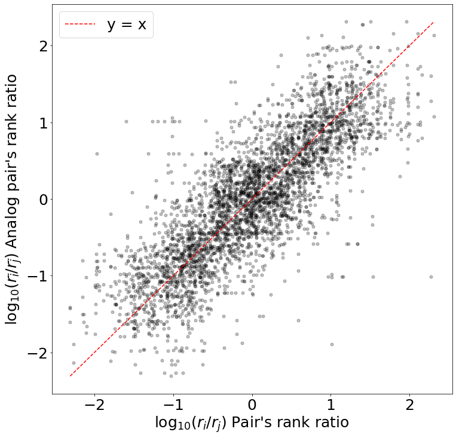

```python
import random as ra
from matplotlib import pyplot as plt

ra.seed(2021)
idx = []
for representatives in analogy_representatives.values():
  idx.append(ra.sample(representatives, 1))
idx = np.array(idx)
left_ratios = np.array(left_ratios); right_ratios = np.array(right_ratios)

fig = plt.figure(figsize = (12,12))
plt.scatter(np.log10(left_ratios)[idx], np.log10(right_ratios)[idx], color = 'black', s = 25, alpha = 0.25)
plt.plot(np.log10([min(left_ratios[idx]), max(left_ratios[idx])]),
         np.log10([min(left_ratios[idx]), max(left_ratios[idx])]),
         color = 'red', linestyle = 'dashed', label = 'y = x')
plt.ylabel(r"$\log_{10}(r_\tilde{i}/r_\tilde{j})$ Analog pair's rank ratio", fontsize = 25)
plt.legend(fontsize = 25)
_ = plt.xlabel(r"$\log_{10}(r_i/r_j)$ Pair's rank ratio", fontsize = 25)
_ = plt.xticks(fontsize=25)
_ = plt.yticks(fontsize=25)
```

#### 1.1.2.3 Analogical comparison reflects the bias contained in data

Okay, so this looks pretty good. Technically, the analogies which are closer top to the $y = x$ axis are those which are most strongly represented by the Google books data. Could this be something we can use to probe data for bias? In other words:

> Does a ranking of analogies by thir distance from the line $y = x$ result in a ranking of the meaning-relationships that are most strongly represented by the data?

From the formula for the [Euclidean distance between a point and a line](https://en.wikipedia.org/wiki/Distance_from_a_point_to_a_line), we can define the *analogical bias* of a data set with respect to any analogy defined by analog-pairs, $x = \{i,j\}$ and $y = \{\tilde{i},\tilde{j}\}$: $$b(x,y) = \frac {\left|\log\frac{r_{i}}{r_{j}} - \log\frac{r_{\tilde{i}}}{r_ {\tilde{j}}}\right|} {\sqrt{2}} $$ It's easy enough to build a function to compute these biases:

```python
def distance(x, y):
  return np.abs(x - y)/(2**0.5)
```

and determine the mean analogical bias (MAB) for the data set:

```python
biases = [distance(np.log10(x),np.log10(y)) for x, y in zip(left_ratios, right_ratios)]
supports = [fs[ranks[x[0]]-1] + fs[ranks[x[1]]-1] + fs[ranks[y[0]]-1] + fs[ranks[y[1]]-1]
            for x, y in zip(lefts, rights)]

MAB = np.abs(biases).dot(supports)/sum(supports)
```

When we plot the MAB in our visualization, we can see the average strength of Google books' relevance to the syntactic analogies in the analogy data set.

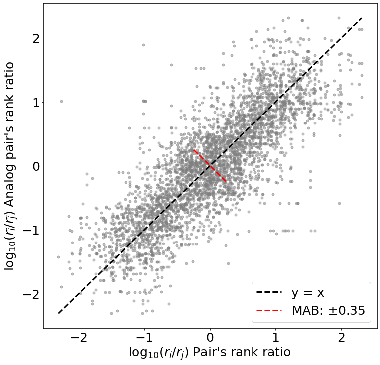

```python
ra.seed(691)
idx = []
for representatives in analogy_representatives.values():
  idx.append(ra.sample(representatives, 1))
idx = np.array(idx)
left_ratios = np.array(left_ratios); right_ratios = np.array(right_ratios)

fig = plt.figure(figsize = (12,12))
plt.scatter(np.log10(left_ratios)[idx], np.log10(right_ratios)[idx], color = 'gray', s = 25, alpha = 0.5)
plt.plot(np.log10([min(left_ratios[idx]), max(left_ratios[idx])]),
         np.log10([min(left_ratios[idx]), max(left_ratios[idx])]),
         color = 'black', linestyle = 'dashed', label = 'y = x', lw = 3)

MAB_x = np.array([-1,1])*MAB/(2**0.5)
MAB_y = np.array([1,-1])*MAB/(2**0.5)
plt.plot(MAB_x, MAB_y, color = 'red', linestyle = 'dashed',
         label = r"MAB: $\pm$"+str(round(MAB, 2)), lw = 3)

plt.ylabel(r"$\log_{10}(r_\tilde{i}/r_\tilde{j})$ Analog pair's rank ratio", fontsize = 25)
plt.legend(fontsize=25)
_ = plt.xlabel(r"$\log_{10}(r_i/r_j)$ Pair's rank ratio", fontsize = 25)
_ = plt.xticks(fontsize=25)
_ = plt.yticks(fontsize=25)
```

It turns out, the MAB is *not* constant for all analogical sets and relates strongly to the analogical arithmetic expressed by word vectors. We think this new theory might explain the prevalence of analogical reasoning in linguistic statistics, but it's unknown what the impact will ultimately be. However, by providing a mathematical relationship that language processing scientists can use to *tune* analogical bias, the potential for greater control and regulation of these 4th-paradigm models is tremendous. Only time and experimental validation will tell, but as we can see, there is a delicate interplay between data, observation, theory, and computation that can sometimes span decades, and which must be negotiated to make progress in science; this requires conscious observation of *all* scientific paradigms.